# Practical Machine Learning Course Project

Jason Lim

Saturday, June 13, 2015

# Introduction

This is the write up for the process that was done to complete the assigned Course Project. The goal of this course project is to utilize the given data and to predict the manner which the exercise is done using techniques learned during the Practical Machine Learning Course.

The training and test data can be obtained as below:

Training : https://d396qusza40orc.cloudfront.net/predmachlearn/pml-training.csv

Test : https://d396qusza40orc.cloudfront.net/predmachlearn/pml-testing.csv

# Data Processing

All the required libraries are loaded 1st :

```r
library(caret)
library(rattle)
```

```r
library(rpart.plot)
library(randomForest)
```

The dataset is then loaded into R Studio, the data **#DIV/0!** from the files are assigned NA status as well.

```r
train <- read.csv("pml-training.csv", na.strings=c("NA","#DIV/0!", ""))
test <- read.csv("pml-testing.csv", na.strings=c("NA","#DIV/0!", ""))
```

```r
train<-train[,!((colSums(is.na(train))/nrow(train)) > 0.8)]
test<-test[,!((colSums(is.na(test))/nrow(test)) > 0.8)]
```

Lastly, as the first 7 columns consists of irrelevant information (Time of exercise, participating Personnel etc), they are excluded as well.

```r
train   <-train[,-c(1:7)]
test <-test[,-c(1:7)]
```

the **nearZeroVar** function is performed to ensure that there’s no variables that have Near Zero Variance, as these will have minimal impact on the prediction and should be removed if exist.

```r
nearZeroVar(train,saveMetrics=TRUE)
```

```
##                      freqRatio percentUnique zeroVar   nzv
## roll_belt             1.101904     6.7781062   FALSE FALSE
## pitch_belt            1.036082     9.3772296   FALSE FALSE
## yaw_belt              1.058480     9.9734991   FALSE FALSE
## total_accel_belt      1.063160     0.1477933   FALSE FALSE
## gyros_belt_x          1.058651     0.7134849   FALSE FALSE
## gyros_belt_y          1.144000     0.3516461   FALSE FALSE
## gyros_belt_z          1.066214     0.8612782   FALSE FALSE
## accel_belt_x          1.055412     0.8357966   FALSE FALSE
## accel_belt_y          1.113725     0.7287738   FALSE FALSE
## accel_belt_z          1.078767     1.5237998   FALSE FALSE
## magnet_belt_x         1.090141     1.6664968   FALSE FALSE
## magnet_belt_y         1.099688     1.5187035   FALSE FALSE
## magnet_belt_z         1.006369     2.3290184   FALSE FALSE
## roll_arm             52.338462    13.5256345   FALSE FALSE
## pitch_arm            87.256410    15.7323412   FALSE FALSE
## yaw_arm              33.029126    14.6570176   FALSE FALSE
## total_accel_arm       1.024526     0.3363572   FALSE FALSE
## gyros_arm_x           1.015504     3.2769341   FALSE FALSE
## gyros_arm_y           1.454369     1.9162165   FALSE FALSE
## gyros_arm_z           1.110687     1.2638875   FALSE FALSE
## accel_arm_x           1.017341     3.9598410   FALSE FALSE
## accel_arm_y           1.140187     2.7367241   FALSE FALSE
## accel_arm_z           1.128000     4.0362858   FALSE FALSE
## magnet_arm_x          1.000000     6.8239731   FALSE FALSE
## magnet_arm_y          1.056818     4.4439914   FALSE FALSE
## magnet_arm_z          1.036364     6.4468454   FALSE FALSE
## roll_dumbbell         1.022388    84.2065029   FALSE FALSE
## pitch_dumbbell        2.277372    81.7449801   FALSE FALSE
## yaw_dumbbell          1.132231    83.4828254   FALSE FALSE
## total_accel_dumbbell  1.072634     0.2191418   FALSE FALSE
## gyros_dumbbell_x      1.003268     1.2282132   FALSE FALSE
## gyros_dumbbell_y      1.264957     1.4167771   FALSE FALSE
## gyros_dumbbell_z      1.060100     1.0498420   FALSE FALSE
## accel_dumbbell_x      1.018018     2.1659362   FALSE FALSE
## accel_dumbbell_y      1.053061     2.3748853   FALSE FALSE
## accel_dumbbell_z      1.133333     2.0894914   FALSE FALSE
## magnet_dumbbell_x     1.098266     5.7486495   FALSE FALSE
## magnet_dumbbell_y     1.197740     4.3012945   FALSE FALSE
## magnet_dumbbell_z     1.020833     3.4451126   FALSE FALSE
## roll_forearm         11.589286    11.0895933   FALSE FALSE
## pitch_forearm        65.983051    14.8557741   FALSE FALSE
## yaw_forearm          15.322835    10.1467740   FALSE FALSE
## total_accel_forearm   1.128928     0.3567424   FALSE FALSE
## gyros_forearm_x       1.059273     1.5187035   FALSE FALSE
## gyros_forearm_y       1.036554     3.7763735   FALSE FALSE
## gyros_forearm_z       1.122917     1.5645704   FALSE FALSE
## accel_forearm_x       1.126437     4.0464784   FALSE FALSE
## accel_forearm_y       1.059406     5.1116094   FALSE FALSE
## accel_forearm_z       1.006250     2.9558659   FALSE FALSE
## magnet_forearm_x      1.012346     7.7667924   FALSE FALSE
## magnet_forearm_y      1.246914     9.5403119   FALSE FALSE
## magnet_forearm_z      1.000000     8.5771073   FALSE FALSE
## classe                1.469581     0.0254816   FALSE FALSE
```

```r
nearZeroVar(test,saveMetrics=TRUE)
```

```
##                      freqRatio percentUnique zeroVar   nzv
## roll_belt                 1.00            90   FALSE FALSE
## pitch_belt                1.00           100   FALSE FALSE
## yaw_belt                  1.00            90   FALSE FALSE
## total_accel_belt          1.20            45   FALSE FALSE
## gyros_belt_x              1.50            70   FALSE FALSE
## gyros_belt_y              2.25            30   FALSE FALSE
## gyros_belt_z              2.50            65   FALSE FALSE
## accel_belt_x              1.00            85   FALSE FALSE
## accel_belt_y              1.50            75   FALSE FALSE
## accel_belt_z              1.00            85   FALSE FALSE
## magnet_belt_x             1.00           100   FALSE FALSE
## magnet_belt_y             1.50            80   FALSE FALSE
## magnet_belt_z             1.50            80   FALSE FALSE
## roll_arm                  8.00            65   FALSE FALSE
## pitch_arm                 8.00            65   FALSE FALSE
## yaw_arm                   8.00            65   FALSE FALSE
## total_accel_arm           1.00            85   FALSE FALSE
## gyros_arm_x               2.00            95   FALSE FALSE
## gyros_arm_y               2.00            95   FALSE FALSE
## gyros_arm_z               1.00            90   FALSE FALSE
## accel_arm_x               2.00            95   FALSE FALSE
## accel_arm_y               1.00           100   FALSE FALSE
## accel_arm_z               1.00           100   FALSE FALSE
## magnet_arm_x              1.00           100   FALSE FALSE
## magnet_arm_y              2.00            95   FALSE FALSE
## magnet_arm_z              1.00           100   FALSE FALSE
## roll_dumbbell             1.00           100   FALSE FALSE
## pitch_dumbbell            1.00           100   FALSE FALSE
## yaw_dumbbell              1.00           100   FALSE FALSE
## total_accel_dumbbell      2.00            70   FALSE FALSE
## gyros_dumbbell_x          1.00            90   FALSE FALSE
## gyros_dumbbell_y          1.00            80   FALSE FALSE
## gyros_dumbbell_z          4.00            85   FALSE FALSE
## accel_dumbbell_x          1.00           100   FALSE FALSE
## accel_dumbbell_y          3.00            90   FALSE FALSE
## accel_dumbbell_z          2.00            95   FALSE FALSE
## magnet_dumbbell_x         1.00           100   FALSE FALSE
## magnet_dumbbell_y         1.00           100   FALSE FALSE
## magnet_dumbbell_z         2.00            95   FALSE FALSE
## roll_forearm              2.00            95   FALSE FALSE
## pitch_forearm             1.00           100   FALSE FALSE
## yaw_forearm               1.00           100   FALSE FALSE
## total_accel_forearm       1.50            65   FALSE FALSE
## gyros_forearm_x           1.00            90   FALSE FALSE
## gyros_forearm_y           1.00           100   FALSE FALSE
## gyros_forearm_z           1.00           100   FALSE FALSE
## accel_forearm_x           1.00           100   FALSE FALSE
## accel_forearm_y           1.00           100   FALSE FALSE
## accel_forearm_z           1.00           100   FALSE FALSE
## magnet_forearm_x          1.00           100   FALSE FALSE
## magnet_forearm_y          1.00           100   FALSE FALSE
## magnet_forearm_z          1.00           100   FALSE FALSE
## problem_id                1.00           100   FALSE FALSE
```

The tests indicate that there are no Near Zero Variance variables for both of the datasets, thus the model building phase can commence.

# Building the Machine Learning Algorithm

The **Training Set** is partitioned into two parts, 60% for **inTraining** and 40% for **inTesting**.

```r
set.seed(2525)
inTrain <- createDataPartition(y=train$classe, p=0.6, list=FALSE)
inTraining <- train[inTrain, ]; inTesting <- train[-inTrain, ]
```

Two different methods will be created and be compared to find out which method will be more suitable to be used for the actual prediction test. The two methods are **Decision Tree** and **Random Forest**.

## Decision Tree

The Decision Tree model is built and displayed:

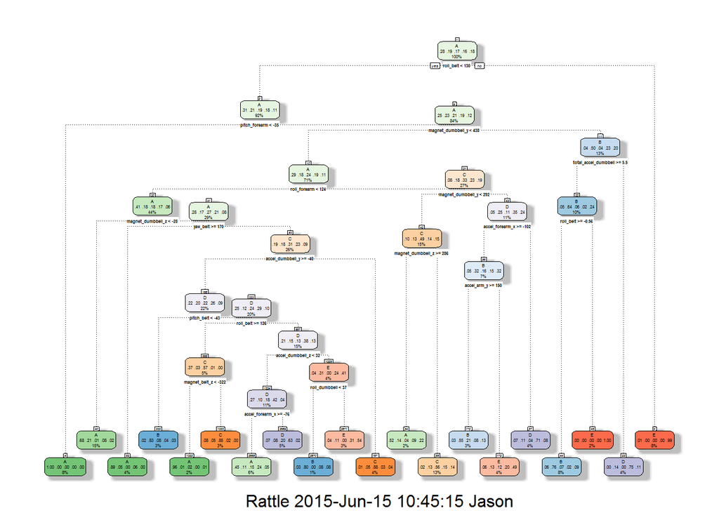

```r
modFitDT <- rpart(classe ~ ., data=inTraining, method="class")
fancyRpartPlot(modFitDT)
```

This model is then used to predict the 40% **inTesting** set and its results are displayed:

```r
predictionsDT <- predict(modFitDT, inTesting, type = "class")
confusionMatrix(predictionsDT, inTesting$classe)
```

```
## Confusion Matrix and Statistics
##
##           Reference
## Prediction    A    B    C    D    E
##          A 2062  356   99  234  114
##          B   44  808  103   57  105
##          C   51  175 1038  190  140
##          D   42  114   90  690   61
##          E   33   65   38  115 1022
##
## Overall Statistics
##
##                Accuracy : 0.7163
##                  95% CI : (0.7062, 0.7262)
##     No Information Rate : 0.2845
##     P-Value [Acc > NIR] : < 2.2e-16
##
##                   Kappa : 0.6374
##  Mcnemar's Test P-Value : < 2.2e-16
##
## Statistics by Class:
##
##                      Class: A Class: B Class: C Class: D Class: E
## Sensitivity            0.9238   0.5323   0.7588  0.53655   0.7087
## Specificity            0.8570   0.9512   0.9142  0.95320   0.9608
## Pos Pred Value         0.7197   0.7234   0.6512  0.69208   0.8028
## Neg Pred Value         0.9659   0.8945   0.9472  0.91298   0.9361
## Prevalence             0.2845   0.1935   0.1744  0.16391   0.1838
## Detection Rate         0.2628   0.1030   0.1323  0.08794   0.1303
## Detection Prevalence   0.3652   0.1424   0.2032  0.12707   0.1622
## Balanced Accuracy      0.8904   0.7417   0.8365  0.74487   0.8348
```

As can be seen, the Accuracy is approximately **72%**. The Random Forest method will now be created and its accuracy be compared with Decision Tree.

## Random Forest

The Random Forest model is built.The model is used to predict the 40% **inTesting** set and its results are displayed:

```r
modFitRF <- randomForest(classe ~ ., data=inTraining)
predictionsRF <- predict(modFitRF, inTesting, type = "class")
confusionMatrix(predictionsRF, inTesting$classe)
```

```
## Confusion Matrix and Statistics
##
##           Reference
## Prediction    A    B    C    D    E
##          A 2231    8    0    0    0
##          B    1 1507   11    0    0
##          C    0    3 1353   16    2
##          D    0    0    4 1269    0
##          E    0    0    0    1 1440
##
## Overall Statistics
##
##                Accuracy : 0.9941
##                  95% CI : (0.9922, 0.9957)
##     No Information Rate : 0.2845
##     P-Value [Acc > NIR] : < 2.2e-16
##
##                   Kappa : 0.9926
##  Mcnemar's Test P-Value : NA
##
## Statistics by Class:
##
##                      Class: A Class: B Class: C Class: D Class: E
## Sensitivity            0.9996   0.9928   0.9890   0.9868   0.9986
## Specificity            0.9986   0.9981   0.9968   0.9994   0.9998
## Pos Pred Value         0.9964   0.9921   0.9847   0.9969   0.9993
## Neg Pred Value         0.9998   0.9983   0.9977   0.9974   0.9997
## Prevalence             0.2845   0.1935   0.1744   0.1639   0.1838
## Detection Rate         0.2843   0.1921   0.1724   0.1617   0.1835
## Detection Prevalence   0.2854   0.1936   0.1751   0.1622   0.1837
## Balanced Accuracy      0.9991   0.9954   0.9929   0.9931   0.9992
```

Due to its high accuracy, the **Random Forest Model** is chosen to be used for predicting the Test Dataset.

# Result Generation

The **Random Tree Model** that was selected is used to predict the **test** set.

```r
submitPredict <- predict(modFitRF, test, type="class")
```

The txt files that were to be submitted to Coursera is generated using the below function :

```r
pml_write_files = function(x){
  n = length(x)
  for(i in 1:n){
    filename = paste0("problem_id_",i,".txt")
    write.table(x[i],file=filename,quote=FALSE,row.names=FALSE,col.names=FALSE)
  }
}
```

The function is called using **pml_write_files(submitPredict)**, 20 result txt files will be generated to the working directory and be used to submit to Coursera.